# Лабораторна робота 4

# Підготовка даних

Завантажимо пакет з набором даних mtcars і перевіримо струтуру датасету

```r
data(mtcars)
str(mtcars)
```

```
'data.frame':   32 obs. of  11 variables:
 $ mpg : num  21 21 22.8 21.4 18.7 18.1 14.3 24.4 22.8 19.2 ...
 $ cyl : num  6 6 4 6 8 6 8 4 4 6 ...
 $ disp: num  160 160 108 258 360 ...
 $ hp  : num  110 110 93 110 175 105 245 62 95 123 ...
 $ drat: num  3.9 3.9 3.85 3.08 3.15 2.76 3.21 3.69 3.92 3.92 ...
 $ wt  : num  2.62 2.88 2.32 3.21 3.44 ...
 $ qsec: num  16.5 17 18.6 19.4 17 ...
 $ vs  : num  0 0 1 1 0 1 0 1 1 1 ...
 $ am  : num  1 1 1 0 0 0 0 0 0 0 ...
 $ gear: num  4 4 4 3 3 3 3 4 4 4 ...
 $ carb: num  4 4 1 1 2 1 4 2 2 4 ...
```

Виведемо декілька перших рядків набору даних

```r
head(mtcars)
```

|  | mpg | cyl | disp | hp | drat | wt | qsec | vs | am | gear | carb |
| --- | --- | --- | --- | --- | --- | --- | --- | --- | --- | --- | --- |
| Mazda RX4 | 21.0 | 6 | 160 | 110 | 3.90 | 2.620 | 16.46 | 0 | 1 | 4 | 4 |
| Mazda RX4 Wag | 21.0 | 6 | 160 | 110 | 3.90 | 2.875 | 17.02 | 0 | 1 | 4 | 4 |
| Datsun 710 | 22.8 | 4 | 108 | 93 | 3.85 | 2.320 | 18.61 | 1 | 1 | 4 | 1 |
| Hornet 4 Drive | 21.4 | 6 | 258 | 110 | 3.08 | 3.215 | 19.44 | 1 | 0 | 3 | 1 |
| Hornet Sportabout | 18.7 | 8 | 360 | 175 | 3.15 | 3.440 | 17.02 | 0 | 0 | 3 | 2 |
| Valiant | 18.1 | 6 | 225 | 105 | 2.76 | 3.460 | 20.22 | 1 | 0 | 3 | 1 |

Статистика змінних

```r
summary(mtcars)
```

```
      mpg             cyl             disp             hp             drat             wt             qsec             vs               am              gear            carb
 Min.   :10.40   Min.   :4.000   Min.   : 71.1   Min.   : 52.0   Min.   :2.760   Min.   :1.513   Min.   :14.50   Min.   :0.0000   Min.   :0.0000   Min.   :3.000   Min.   :1.000
 1st Qu.:15.43   1st Qu.:4.000   1st Qu.:120.8   1st Qu.: 96.5   1st Qu.:3.080   1st Qu.:2.581   1st Qu.:16.89   1st Qu.:0.0000   1st Qu.:0.0000   1st Qu.:3.000   1st Qu.:2.000
 Median :19.20   Median :6.000   Median :196.3   Median :123.0   Median :3.695   Median :3.325   Median :17.71   Median :0.0000   Median :0.0000   Median :4.000   Median :2.000
 Mean   :20.09   Mean   :6.188   Mean   :230.7   Mean   :146.7   Mean   :3.597   Mean   :3.217   Mean   :17.85   Mean   :0.4375   Mean   :0.4062   Mean   :3.688   Mean   :2.812
 3rd Qu.:22.80   3rd Qu.:8.000   3rd Qu.:326.0   3rd Qu.:180.0   3rd Qu.:3.920   3rd Qu.:3.610   3rd Qu.:18.90   3rd Qu.:1.0000   3rd Qu.:1.0000   3rd Qu.:4.000   3rd Qu.:4.000
 Max.   :33.90   Max.   :8.000   Max.   :472.0   Max.   :335.0   Max.   :4.930   Max.   :5.424   Max.   :22.90   Max.   :1.0000   Max.   :1.0000   Max.   :5.000   Max.   :8.000
```

# Проста лінійна регресія

Побудуємо регресію

```r
lm_simple <- lm(mpg ~ am, data = mtcars)
```

Виведемо коефіцієнтів

```r
summary(lm_simple)
```

```
Call:
lm(formula = mpg ~ am, data = mtcars)

Residuals:
    Min      1Q  Median      3Q     Max
-9.3923 -3.0923 -0.2974  3.2439  9.5077

Coefficients:
            Estimate Std. Error t value Pr(>|t|)
(Intercept)   17.147      1.125  15.247 1.13e-15 ***
am             7.245      1.764   4.106 0.000285 ***
---
Signif. codes:  0 ‘***’ 0.001 ‘**’ 0.01 ‘*’ 0.05 ‘.’ 0.1 ‘ ’ 1

Residual standard error: 4.902 on 30 degrees of freedom
Multiple R-squared:  0.3598,    Adjusted R-squared:  0.3385
F-statistic: 16.86 on 1 and 30 DF,  p-value: 0.000285
```

Перевірка статистичних вимог

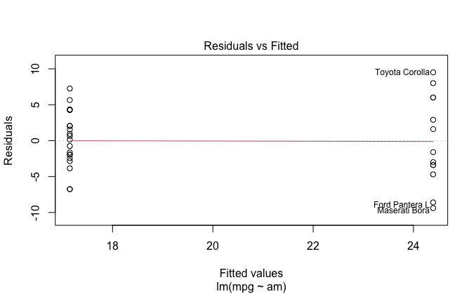

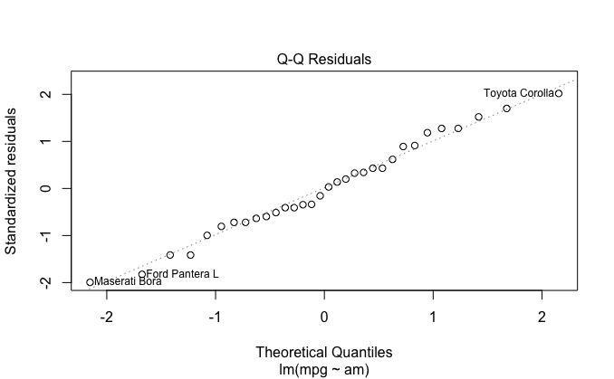

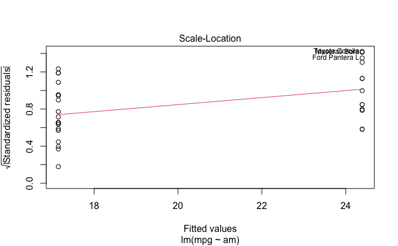

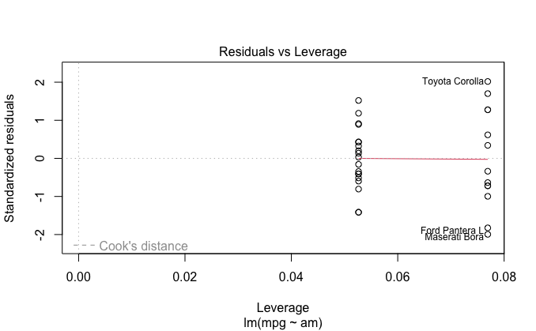

```r
plot(lm_simple)
```

# Множинна лінійна регресія

Побудуємо регресію

```r
lm_multiple <- lm(mpg ~ am + cyl + hp + wt, data = mtcars)
```

Виведемо коефіцієнтів

```r
summary(lm_multiple)
```

```
Call:
lm(formula = mpg ~ am + cyl + hp + wt, data = mtcars)

Residuals:
    Min      1Q  Median      3Q     Max
-3.4765 -1.8471 -0.5544  1.2758  5.6608

Coefficients:
            Estimate Std. Error t value Pr(>|t|)
(Intercept) 36.14654    3.10478  11.642 4.94e-12 ***
am           1.47805    1.44115   1.026   0.3142
cyl         -0.74516    0.58279  -1.279   0.2119
hp          -0.02495    0.01365  -1.828   0.0786 .
wt          -2.60648    0.91984  -2.834   0.0086 **
---
Signif. codes:  0 ‘***’ 0.001 ‘**’ 0.01 ‘*’ 0.05 ‘.’ 0.1 ‘ ’ 1

Residual standard error: 2.509 on 27 degrees of freedom
Multiple R-squared:  0.849, Adjusted R-squared:  0.8267
F-statistic: 37.96 on 4 and 27 DF,  p-value: 1.025e-10
```

Перевірка статистичних вимог

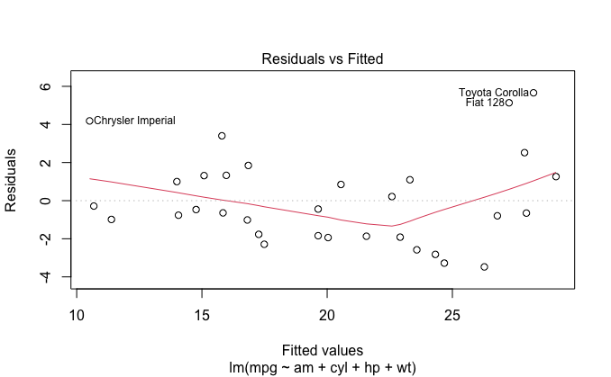

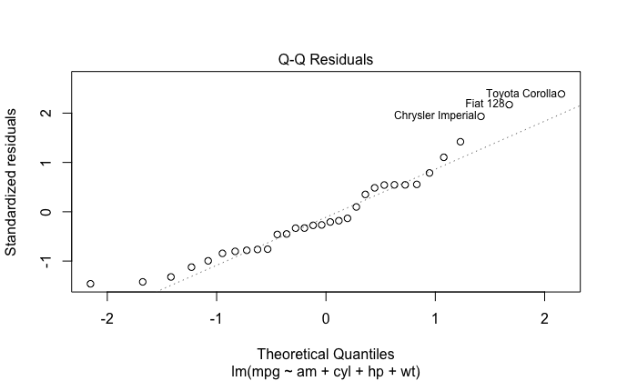

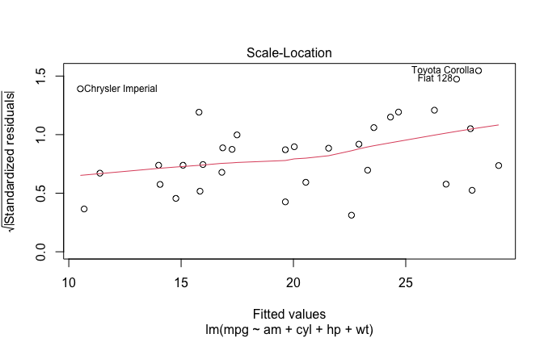

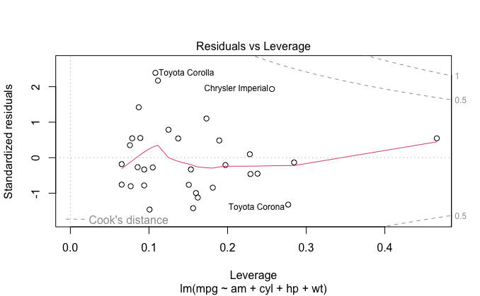

```r
plot(lm_multiple)
```

# Порівняня моделей

Середні значення миль на галон для автоматичних (0) та ручних (1) коробок

```r
predicted_simple <- predict(lm_simple, data.frame(am = c(0, 1)))
predicted_multiple <- predict(lm_multiple, data.frame(am = c(0, 1), cyl = mean(mtcars$cyl), hp = mean(mtcars$hp), wt = mean(mtcars$wt)))
predicted_simple
```

```
       1        2
17.14737 24.39231
```

```r
predicted_multiple
```

```
       1        2
19.49017 20.96822
```

Статистичні дані

```r
r_squared_simple <- summary(lm_simple)$r.squared
r_squared_multiple <- summary(lm_multiple)$r.squared

rmse_simple <- sqrt(mean(lm_simple$residuals^2))
rmse_multiple <- sqrt(mean(lm_multiple$residuals^2))

aic_simple <- AIC(lm_simple)
aic_multiple <- AIC(lm_multiple)

print("Проста лінійна регресія:")
```

```
[1] "Проста лінійна регресія:"
```

```r
print(paste("R-квадрат:", r_squared_simple))
```

```
[1] "R-квадрат: 0.359798943425465"
```

```r
print(paste("RMSE:", rmse_simple))
```

```
[1] "RMSE: 4.74636900427014"
```

```r
print(paste("AIC:", aic_simple))
```

```
[1] "AIC: 196.484380081888"
```

```r
print("-------------------------")
```

```
[1] "-------------------------"
```

```r
print("Множинна лінійна регресія:")
```

```
[1] "Множинна лінійна регресія:"
```

```r
print(paste("R-квадрат:", r_squared_multiple))
```

```
[1] "R-квадрат: 0.849031398434848"
```

```r
print(paste("RMSE:", rmse_multiple))
```

```
[1] "RMSE: 2.30487099146329"
```

```r
print(paste("AIC:", aic_multiple))
```

```
[1] "AIC: 156.253647301796"
```

1. **Коефіцієнт детермінації (R-квадрат)** показує, наскільки добре модель пояснює варіацію у відгуках. Чим ближче значення R-квадрат до 1, тим краще модель пояснює дані.
2. **Корень середньоквадратичної помилки (RMSE)** - це середнє квадратичне відхилення між спостереженими і передбаченими значеннями. Чим менше значення RMSE, тим краще модель передбачає дані.
3. **Критерій Акаіке (AIC)** - це метрика, яка оцінює якість моделі, враховуючи її точність і складність. Чим менше значення AIC, тим краще модель.

За кожним з цих критеріїв можна зробити висновок, що множинна лінійна регресія є точнішою моделлю для передбачення зв’язку між типом коробки передач та милями на галон порівняно з простою лінійною регресією.

# Висновок

За результатами передбачень обох моделей, миль на галон для автомобілів з ручною коробкою передач вищі, ніж для автомобілів з автоматичною коробкою передач. Отже, на основі цих даних можна зробити висновок, що автомобілі з ручною коробкою передач мають тенденцію до кращої ефективності пального, оскільки вони забезпечують більшу витрату миль на галон.